# Household Transmission of SARS-CoV-2: Insights from a Population-based Serological Survey

Qifang Bi, Andrew Azman, Justin Lessler

10/3/2020

### First generate stan model output for all 9 models + other sensitivity analyses

### or, load pregenerated stan model output

### Figure 1. Epidemic curve and recruitment period

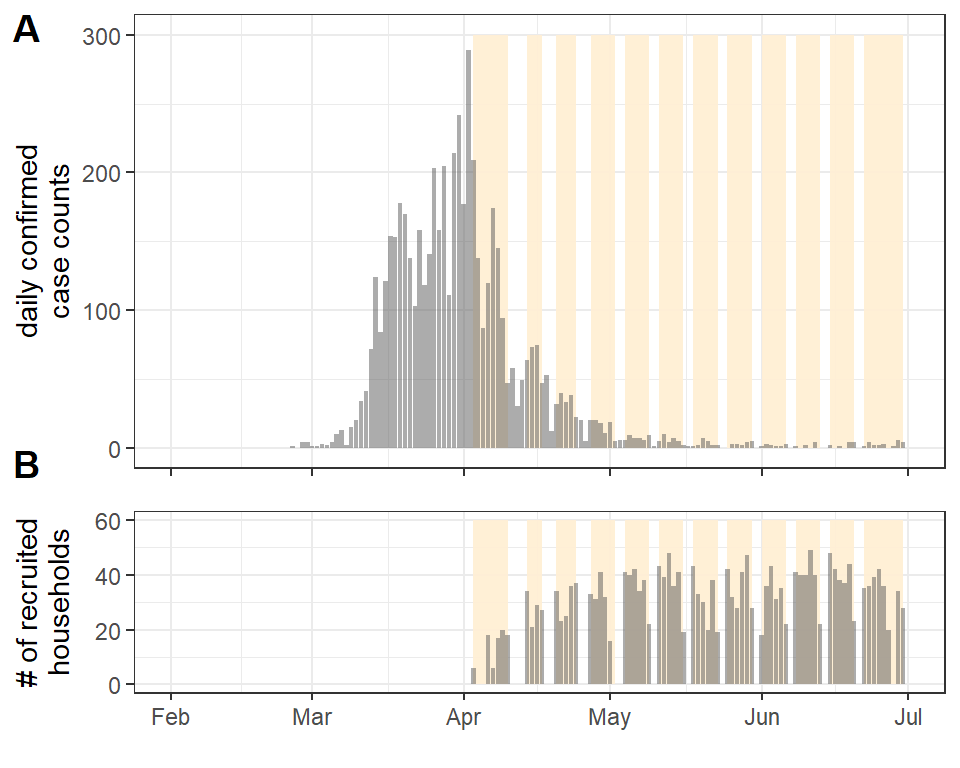

### Figure 2. Estimated median probability of infection

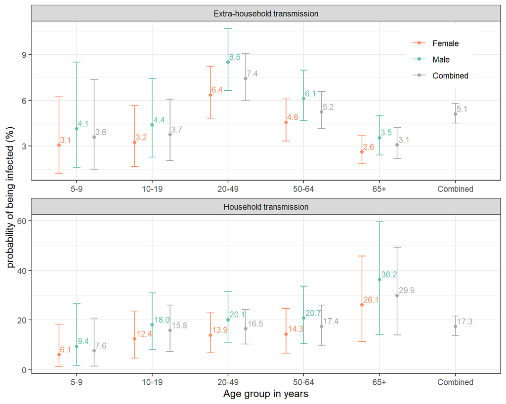

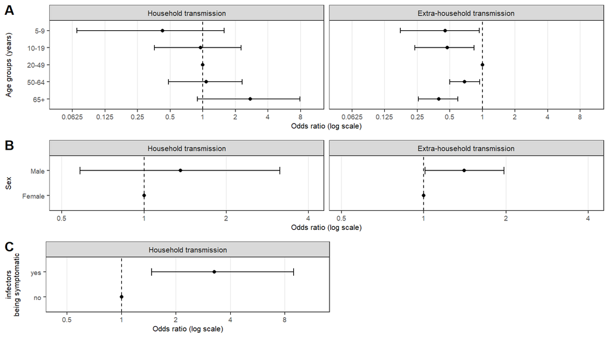

### SFigure 2. Frequency of households of different sizes in the study, proportion seropositive by household size, and distribution of the number of seropositive people in household by size

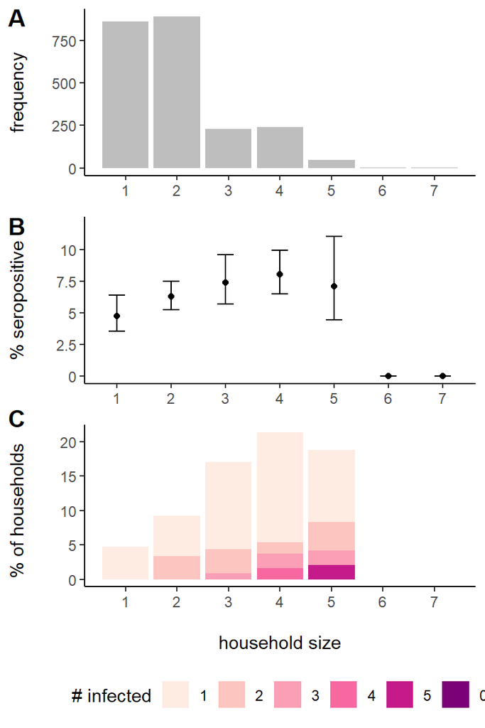

### SFigure 3. Figure representation of Table 1

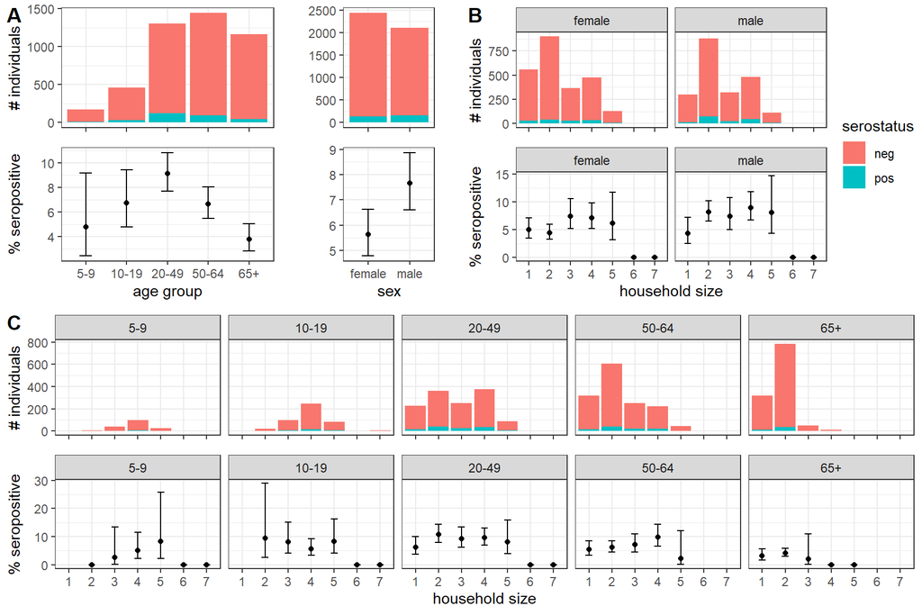

### Table 1. Number of recruited and seropositive individuals by age-group, sex and household size of the households they reside in.

| my_var | hhsize1 | hhsize2 | hhsize3 | hhsize4 | hhsize5 | overall | OR |
| --- | --- | --- | --- | --- | --- | --- | --- |
| **HOUSEHOLDS** |  |  |  |  |  |  |  |
| 0 | 819/860 95%(94,96) | 807/889 91%(89,93) | 190/229 83%(78,87) | 188/239 79%(73,83) | 41/50 82%(69,90) | 2045/2267 90%(89,91) | NA |
| 1 | 41/860 5%(4,6) | 52/889 6%(4,8) | 29/229 13%(9,18) | 38/239 16%(12,21) | 5/50 10%(4,21) | 165/2267 7%(6,8) | NA |
| 1+ | NA | 30/889 3%(2,5) | 10/229 4%(2,8) | 13/239 5%(3,9) | 4/50 8%(3,19) | 57/2267 3%(2,3) | NA |
| **INDIVIDUALS** |  |  |  |  |  |  |  |
| **Age** |  |  |  |  |  |  |  |
| 5-9 | NA | 0/6 0%(0,0) | 1/38 3%(0,13) | 5/97 5%(2,12) | 2/26 8%(2,24) | 8/167 5%(2,9) | 0.5 (0.2,1.0) |
| 10-19 | NA | 2/21 10%(3,29) | 8/99 8%(4,15) | 14/248 6%(3,9) | 7/91 8%(4,15) | 31/459 7%(5,9) | 0.7 (0.5,1.1) |
| 20-49 | 14/227 6%(4,10) | 39/361 11%(8,14) | 23/249 9%(6,13) | 36/375 10%(7,13) | 7/90 8%(4,15) | 119/1302 9%(8,11) | NA |
| 50-64 | 17/316 5%(3,8) | 38/607 6%(5,8) | 18/253 7%(5,11) | 22/224 10%(7,14) | 1/43 2%(0,12) | 96/1443 7%(5,8) | 0.7 (0.5,0.9) |
| 65+ | 10/317 3%(2,6) | 33/783 4%(3,6) | 1/48 2%(0,11) | 0/12 0%(0,0) | 0/3 0%(0,0) | 44/1163 4%(3,5) | 0.4 (0.3,0.6) |
| **Sex** |  |  |  |  |  |  |  |
| female | 28/558 5%(3,7) | 40/900 4%(3,6) | 27/364 7%(5,11) | 34/475 7%(5,10) | 8/135 6%(3,11) | 137/2432 6%(5,7) | NA |
| male | 13/302 4%(3,7) | 72/878 8%(7,10) | 24/323 7%(5,11) | 43/481 9%(7,12) | 9/118 8%(4,14) | 161/2102 8%(7,9) | 1.4 (1.1,1.8) |
| **Symptom** |  |  |  |  |  |  |  |
| asym | 7/602 1%(1,2) | 36/1278 3%(2,4) | 19/451 4%(3,6) | 24/643 4%(3,5) | 5/176 3%(1,6) | 91/3150 3%(2,4) | NA |
| sym | 34/258 13%(10,18) | 76/500 15%(12,19) | 32/236 14%(10,19) | 53/313 17%(13,21) | 12/77 16%(9,25) | 207/1384 15%(13,17) | 5.9 (4.6,7.7) |
| **Reduced contact** |  |  |  |  |  |  |  |
| Oui | 33/788 4%(3,6) | 107/1672 6%(5,8) | 40/569 7%(5,9) | 63/707 9%(7,11) | 11/178 6%(3,11) | 254/3914 6%(6,7) | 0.8 (0.5,1.5) |
| Non | 8/71 11%(6,21) | 1/70 1%(0,8) | 5/37 14%(6,28) | 3/39 8%(3,20) | 0/7 0%(0,0) | 17/224 8%(5,12) | NA |
| NA | 0/1 0%(0,0) | 4/36 11%(4,25) | 6/81 7%(3,15) | 11/210 5%(3,9) | 6/68 9%(4,18) | 27/396 7%(5,10) | NA |
| **Number of extra-HH contacts/week** |  |  |  |  |  |  |  |
| 0 | 3/64 5%(2,13) | 14/188 7%(4,12) | 7/72 10%(5,19) | 5/88 6%(2,13) | 1/12 8%(0,35) | 30/424 7%(5,10) | NA |
| 1 à 2 | 10/207 5%(3,9) | 26/375 7%(5,10) | 7/134 5%(3,10) | 15/180 8%(5,13) | 2/49 4%(1,14) | 60/945 6%(5,8) | 0.9 (0.6,1.4) |
| 3 à 5 | 12/283 4%(2,7) | 32/563 6%(4,8) | 7/158 4%(2,9) | 12/152 8%(5,13) | 3/47 6%(2,17) | 66/1203 5%(4,7) | 0.8 (0.5,1.2) |
| 6 à 10 | 10/115 9%(5,15) | 22/266 8%(6,12) | 8/86 9%(5,17) | 12/132 9%(5,15) | 1/26 4%(0,19) | 53/625 8%(7,11) | 1.2 (0.8,2.0) |
| plus de 10 | 6/190 3%(1,7) | 14/350 4%(2,7) | 16/156 10%(6,16) | 22/194 11%(8,17) | 4/51 8%(3,18) | 62/941 7%(5,8) | 0.9 (0.6,1.5) |
| NA | 0/1 0%(0,0) | 4/36 11%(4,25) | 6/81 7%(3,15) | 11/210 5%(3,9) | 6/68 9%(4,18) | 27/396 7%(5,10) | NA |
| **Overall** |  |  |  |  |  |  |  |
| overall | 41/860 5%(4,6) | 112/1778 6%(5,8) | 51/687 7%(6,10) | 77/956 8%(6,10) | 17/253 7%(4,10) | 298/4534 7% (6,7) | NA |

### SFigure 4. sensitivity analyses, by sero-positivity definition

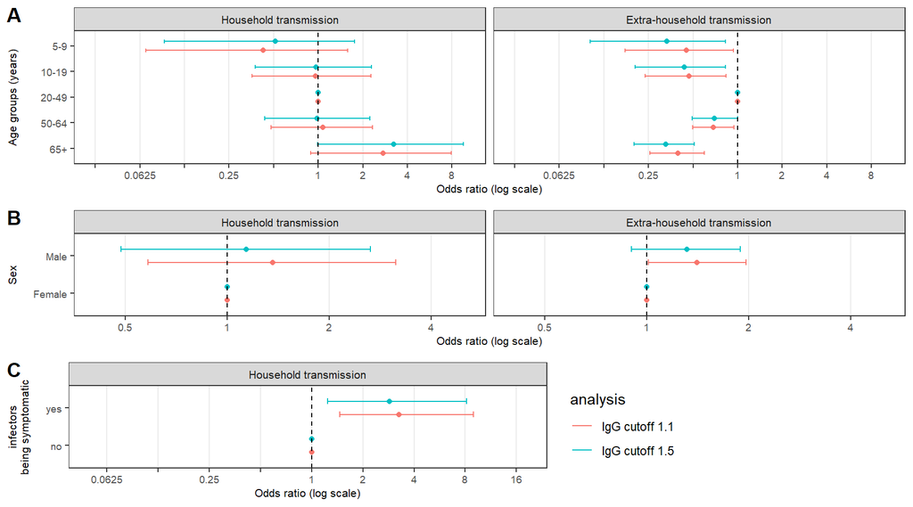

### SFigure 5. sensitivity analyses, by enrollment week

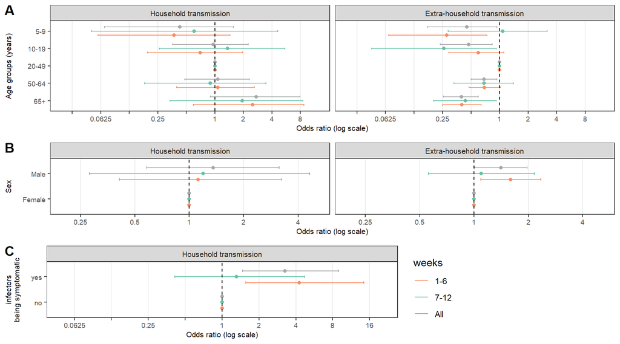

### SFigure 6. sensitivity analyses, by definition of symptomatic infections

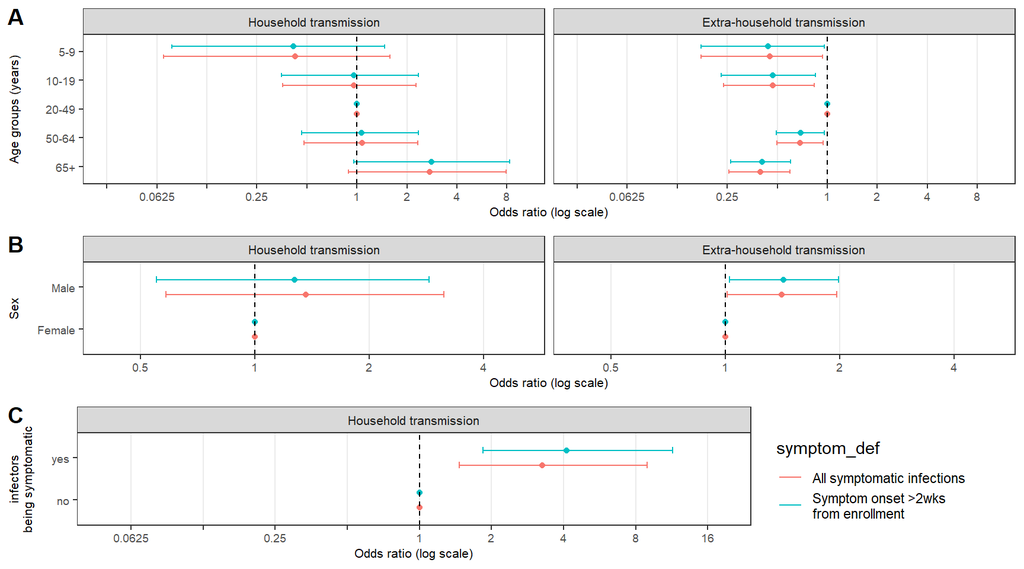

### SFigure 7. Prob of infection by weeks

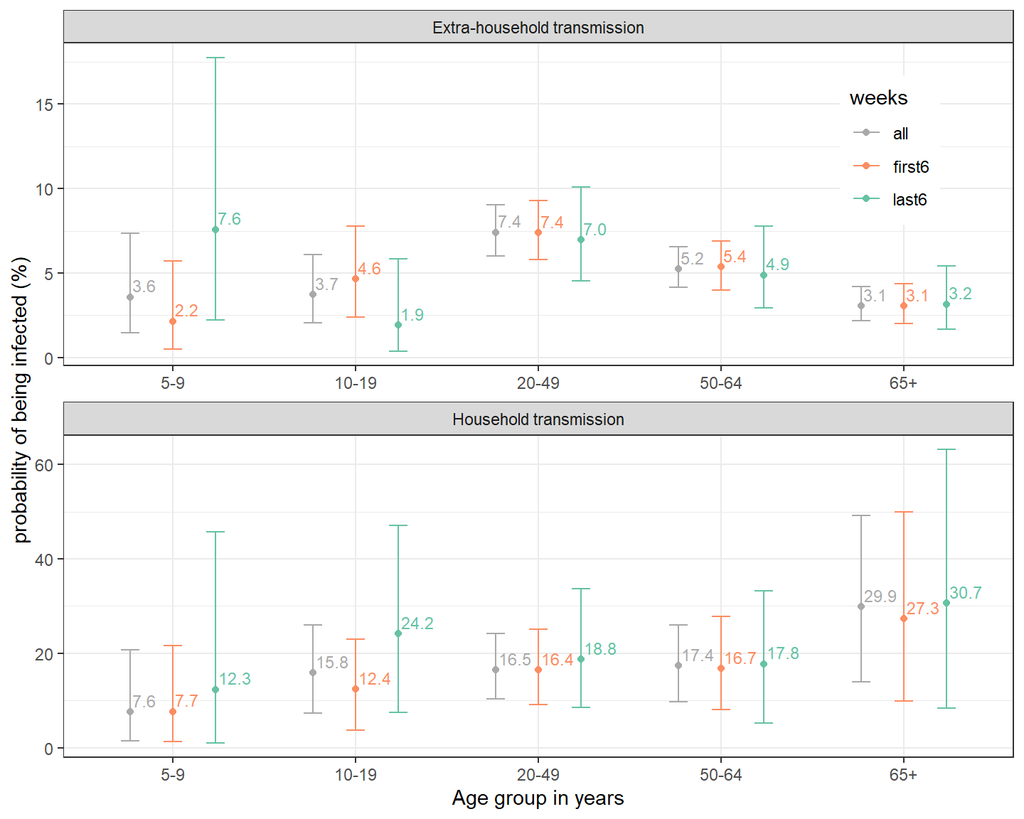

### SFigure 8. Proportion of infections that occurred within a household of various household sizes

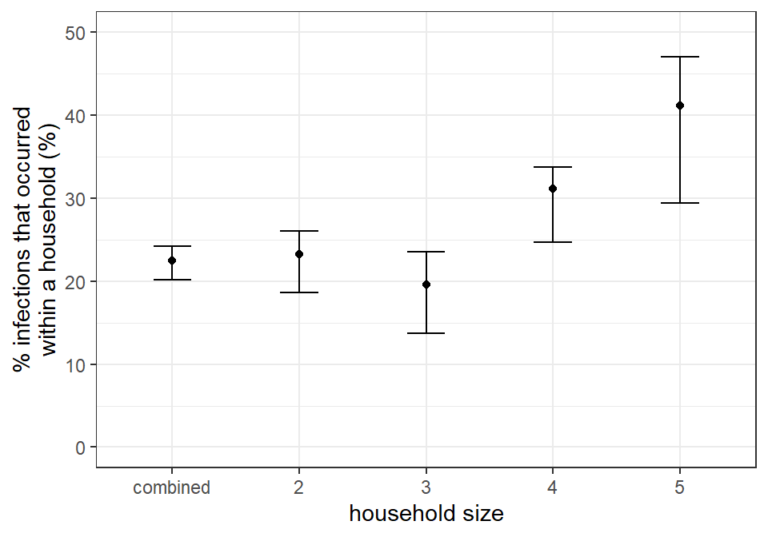

### SFigure 9. Distribution of the total number of transmission generations within a household by number of seropositives in a household.

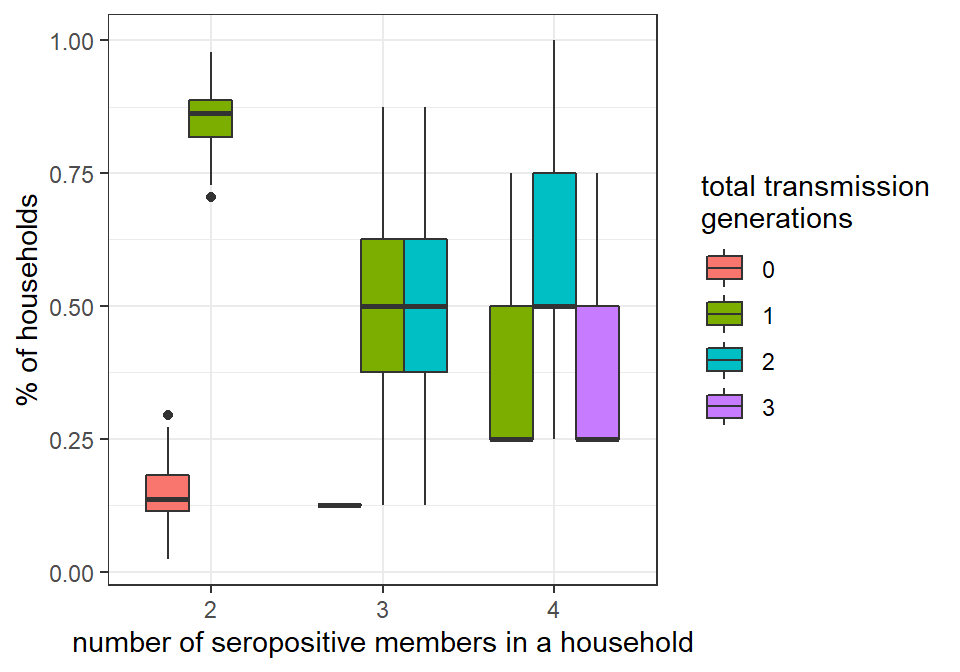

### STable 1. Household composition over the study period.

| week | total HH | % HH with <10yrs old (n) | % HH with >65yrs old (n) | % HH size = 1 (n) | average HH size (IQR) |
| --- | --- | --- | --- | --- | --- |
| 1 | 85 | 11.8% (10) | 18.8% (16) | 30.6% (26) | 2.33 (1, 3) |
| 2 | 111 | 5.4% (6) | 27.9% (31) | 29.7% (33) | 2.19 (1, 3) |
| 3 | 155 | 3.2% (5) | 32.9% (51) | 41.9% (65) | 1.95 (1, 2) |
| 4 | 153 | 9.8% (15) | 28.1% (43) | 33.3% (51) | 2.12 (1, 3) |
| 5 | 217 | 8.8% (19) | 25.8% (56) | 38.7% (84) | 2.07 (1, 3) |
| 6 | 226 | 4.9% (11) | 31.9% (72) | 35% (79) | 2.04 (1, 2) |
| 7 | 183 | 9.8% (18) | 31.1% (57) | 25.1% (46) | 2.33 (1.5, 3) |
| 8 | 218 | 2.3% (5) | 39.4% (86) | 45% (98) | 1.83 (1, 2) |
| 9 | 185 | 6.5% (12) | 40.5% (75) | 39.5% (73) | 1.98 (1, 2) |
| 10 | 232 | 4.7% (11) | 36.2% (84) | 37.9% (88) | 1.92 (1, 2) |
| 11 | 232 | 3.4% (8) | 47.4% (110) | 40.1% (93) | 1.81 (1, 2) |
| 12 | 270 | 4.4% (12) | 48.5% (131) | 45.9% (124) | 1.84 (1, 2) |
| all | 2267 | 5.8% (132) | 35.8% (812) | 37.9% (860) | 2 (1, 2) |

### STable 2. Outputs from models 1-3

| Category | Model 1; age Extra-household Odds Ratio (95% CI) | Model 1; age Within Household Odds Ratio (95% CI) | Model 2; age + sex Extra-household Odds Ratio (95% CI) | Model 2; age + sex Within Household Odds Ratio (95% CI) | Model 3; age/sex interaction Extra-household Odds Ratio (95% CI) | Model 3; age/sex interaction Within Household Odds Ratio (95% CI) |
| --- | --- | --- | --- | --- | --- | --- |
| **Age** |  |  |  |  |  |  |
| 5-9 | 0.5 (0.2, 1.0) | 0.4 (0.1, 1.4) | 0.5 (0.2, 1.0) | 0.4 (0.1, 1.5) | 0.4 (0.1, 1.1) | 0.3 (0.0, 1.4) |
| 10-19 | 0.5 (0.2, 0.9) | 0.9 (0.3, 2.3) | 0.5 (0.2, 0.9) | 0.9 (0.3, 2.1) | 0.4 (0.1, 0.9) | 1.4 (0.4, 4.6) |
| 50-64 | 0.7 (0.5, 1.0) | 1.1 (0.5, 2.3) | 0.7 (0.5, 1.0) | 1.0 (0.4, 2.4) | 0.6 (0.4, 1.0) | 0.8 (0.2, 2.6) |
| 65+ | 0.4 (0.3, 0.6) | 2.2 (0.7, 5.6) | 0.4 (0.3, 0.6) | 2.2 (0.8, 5.9) | 0.3 (0.2, 0.6) | 1.1 (0.2, 4.3) |
| **Sex** |  |  |  |  |  |  |
| Male | NA | NA | 1.4 (1.0, 1.9) | 1.6 (0.6, 3.9) | 1.1 (0.7, 1.7) | 1.6 (0.5, 5.2) |
| **Age-sex interaction** |  |  |  |  |  |  |
| 5-9M | NA | NA | NA | NA | 1.3 (0.3, 6.1) | 1.7 (0.2, 13.1) |
| 10-19M | NA | NA | NA | NA | 1.4 (0.5, 4.7) | 0.4 (0.1, 2.1) |
| 50-64M | NA | NA | NA | NA | 1.3 (0.7, 2.6) | 1.6 (0.3, 9.1) |
| 65+M | NA | NA | NA | NA | 1.5 (0.7, 3.5) | 5.2 (0.7, 43.7) |

### STable 2. Outputs models 4-6

| Category | Model 4: age + sex + symptom Extra-household Odds Ratio (95% CI) | Model 4: age + sex + symptom Within Household Odds Ratio (95% CI) | Model 5: Model 4 + reduced contact Extra-household Odds Ratio (95% CI) | Model 5: Model 4 + reduced contact Within Household Odds Ratio (95% CI) | Model 6: Model 4 + reduced contact + extra HH contacts Extra-household Odds Ratio (95% CI) | Model 6: Model 4 + reduced contact + extra HH contacts Within Household Odds Ratio (95% CI) |
| --- | --- | --- | --- | --- | --- | --- |
| **Age** |  |  |  |  |  |  |
| 5-9 | 0.5 (0.2, 0.9) | 0.4 (0.1, 1.6) | 0.3 (0.1, 0.8) | 0.4 (0.1, 1.4) | 0.4 (0.1, 1.3) | 0.4 (0.1, 1.4) |
| 10-19 | 0.5 (0.2, 0.8) | 1.0 (0.4, 2.3) | 0.3 (0.2, 0.7) | 0.9 (0.3, 2.2) | 0.4 (0.1, 1.2) | 0.9 (0.3, 2.1) |
| 50-64 | 0.7 (0.5, 0.9) | 1.1 (0.5, 2.3) | 0.7 (0.5, 1.0) | 1.1 (0.5, 2.3) | 0.7 (0.5, 1.0) | 1.0 (0.4, 2.2) |
| 65+ | 0.4 (0.3, 0.6) | 2.7 (0.9, 7.9) | 0.2 (0.1, 0.9) | 2.7 (0.9, 7.4) | 0.3 (0.0, 1.5) | 2.8 (1.0, 7.5) |
| **Sex** |  |  |  |  |  |  |
| Male | 1.4 (1.0, 2.0) | 1.4 (0.6, 3.1) | 1.4 (1.0, 1.9) | 1.4 (0.6, 3.2) | 1.4 (1.0, 1.9) | 1.3 (0.6, 3.0) |
| **Symptomatic** |  |  |  |  |  |  |
| sym | NA | 3.3 (1.5, 8.9) | NA | 3.3 (1.5, 8.4) | NA | 3.4 (1.5, 8.5) |
| **Reduced contact among 20-64 yo** |  |  |  |  |  |  |
| age2064:reduced_contact | NA | NA | 0.7 (0.4, 1.2) | NA | 0.7 (0.4, 1.2) | NA |
| **Reduced contact among 65+ yo** |  |  |  |  |  |  |
| age65+:reduced_contact | NA | NA | 1.1 (0.4, 4.3) | NA | 1.1 (0.3, 5.7) | NA |
| **Extra HH contacts among 20-64 yo** |  |  |  |  |  |  |
| age2064:0 | NA | NA | NA | NA | 1.6 (0.9, 2.9) | NA |
| age2064:1 à 2 | NA | NA | NA | NA | 1.2 (0.7, 2.0) | NA |
| age2064:6 à 10 | NA | NA | NA | NA | 1.8 (1.1, 3.0) | NA |
| age2064:plus de 10 | NA | NA | NA | NA | 1.2 (0.7, 1.9) | NA |
| **Extra HH contacts among 65+ yo** |  |  |  |  |  |  |
| age65+:0 | NA | NA | NA | NA | 0.5 (0.1, 1.8) | NA |
| age65+:1 à 2 | NA | NA | NA | NA | 1.6 (0.7, 4.1) | NA |
| age65+:6 à 10 | NA | NA | NA | NA | 2.0 (0.8, 5.2) | NA |
| age65+:plus de 10 | NA | NA | NA | NA | 0.4 (0.1, 1.7) | NA |

## STable 2. Outputs from models 7-9

| Category | Model 7: infectors’ age/sex + infectors’ age Extra-household Odds Ratio (95% CI) | Model 7: infectors’ age/sex + infectors’ age Within a household Odds Ratio (95% CI) | Model 8: infectees’ sex + infectors’ age Extra-household Odds Ratio (95% CI) | Model 8: infectees’ sex + infectors’ age Within a household Odds Ratio (95% CI) | Model 9: Model 2 + infectors’ age Extra-household Odds Ratio (95% CI) | Model 9: Model 2 + infectors’ age Within a household Odds Ratio (95% CI) |
| --- | --- | --- | --- | --- | --- | --- |
| **Age of infectees** |  |  |  |  |  |  |
| 5-9 | 0.4 (0.2, 1.0) | 0.4 (0.1, 1.5) | NA | NA | 0.5 (0.2, 1.0) | 0.5 (0.1, 1.6) |
| 10-19 | 0.6 (0.2, 1.1) | 0.7 (0.2, 2.2) | NA | NA | 0.5 (0.2, 1.1) | 0.7 (0.1, 2.3) |
| 50-64 | 0.7 (0.5, 1.0) | 1.0 (0.4, 2.5) | NA | NA | 0.7 (0.5, 1.0) | 0.9 (0.3, 2.2) |
| 65+ | 0.4 (0.3, 0.6) | 1.8 (0.4, 9.0) | NA | NA | 0.4 (0.3, 0.6) | 2.1 (0.4, 8.0) |
| **Sex** |  |  |  |  |  |  |
| Male | 1.4 (1.0, 2.0) | 1.3 (0.5, 3.2) | 1.5 (1.1, 2.1) | 1.1 (0.5, 2.4) | 1.4 (1.0, 1.9) | 1.6 (0.7, 4.0) |
| **Symptomatic** |  |  |  |  |  |  |
| alpha_sym | NA | 3.6 (1.5, 10.4) | NA | 3.9 (1.7, 10.6) | NA | NA |
| **Age of infectors** |  |  |  |  |  |  |
| alpha5-9 | NA | 0.7 (0.0, 4.7) | NA | 0.7 (0.0, 4.7) | NA | 0.5 (0.0, 2.8) |
| alpha10-19 | NA | 1.9 (0.2, 6.8) | NA | 1.9 (0.2, 6.8) | NA | 1.9 (0.2, 6.8) |
| alpha50-64 | NA | 1.2 (0.4, 3.6) | NA | 1.2 (0.4, 3.6) | NA | 1.2 (0.4, 3.6) |
| alpha65+ | NA | 1.9 (0.3, 8.7) | NA | 1.9 (0.3, 8.7) | NA | 1.9 (0.3, 8.7) |

### STable 2. Model performance

| model | waic | delta_waic |
| --- | --- | --- |
| model0 | 2006.908 | 0.00000 |
| model1 | 1992.135 | -14.77317 |
| model2 | 1986.719 | -20.18896 |
| model3 | 1987.754 | -19.15403 |
| model4 | 1977.342 | -29.56585 |
| model5 | 1977.519 | -29.38908 |
| model6 | 1976.897 | -30.01148 |
| model7 | 1982.200 | -24.70796 |
| model8 | 1991.846 | -15.06215 |
| model9 | 1991.426 | -15.48261 |

### STable 3. Attributable fraction of extra-household infections, within household infections by symptomatics, and within household infections by asymptomatics

model0

model1

model2

model3

model4

model5

model6

model7

model8

model9

2

23.2 (18.6, 25.9)

23.2 (19.6, 25.9)

23.2 (19.5, 26.8)

23.2 (18.8, 25.9)

23.2 (18.6, 26.0)

23.2 (19.6, 26.8)

23.2 (19.6, 25.9)

23.2 (19.5, 25.9)

23.2 (20.3, 26.0)

23.2 (20.5, 25.9)

3

21.6 (17.4, 23.5)

21.6 (15.7, 23.5)

19.6 (15.4, 23.5)

19.6 (17.4, 23.5)

19.6 (13.7, 23.5)

21.6 (15.7, 23.5)

19.6 (15.7, 23.5)

19.6 (15.7, 23.5)

19.6 (13.7, 23.5)

19.6 (15.7, 23.5)

4

31.2 (25.8, 33.8)

29.9 (25.8, 33.8)

29.9 (24.7, 32.7)

29.9 (26.0, 33.8)

31.2 (24.7, 33.8)

29.9 (27.3, 33.8)

31.2 (26.9, 33.8)

29.9 (26.0, 33.8)

29.9 (25.6, 33.8)

29.9 (26.0, 33.8)

5

41.2 (35.3, 47.1)

41.2 (28.5, 47.1)

41.2 (28.5, 47.1)

41.2 (29.4, 47.1)

41.2 (29.4, 47.1)

41.2 (29.4, 47.1)

41.2 (29.4, 47.1)

41.2 (29.4, 47.1)

41.2 (35.3, 47.1)

41.2 (29.4, 47.1)

all

22.5 (20.1, 24.5)

22.5 (20.1, 24.2)

22.5 (19.7, 23.9)

22.1 (20.1, 24.2)

22.5 (20.1, 24.2)

22.5 (20.4, 24.2)

22.5 (20.8, 23.9)

22.1 (20.4, 24.5)

22.5 (20.1, 24.5)

22.1 (20.8, 23.9)

14.9 (8.5, 22.3)

13.8 (7.5, 21.2)

14.1 (8.9, 20.6)

14.1 (7.6, 20.1)

### STable 4. Numbers in Fig 2

| Age group | Extra-household transmission (95%CI) combined | Extra-household transmission (95%CI) male | Extra-household transmission (95%CI) female | Household transmission combined | Household transmission male | Household transmission female |
| --- | --- | --- | --- | --- | --- | --- |
| 5-9 | 3.6 (1.4, 7.4) | 4.1 (1.6, 8.5) | 3.1 (1.2, 6.2) | 7.6 (1.4, 20.7) | 9.4 (1.7, 26.6) | 6.1 (1.3, 18.1) |
| 10-19 | 3.7 (2.0, 6.1) | 4.4 (2.3, 7.4) | 3.2 (1.7, 5.7) | 15.8 (7.4, 26.1) | 18.0 (8.2, 30.9) | 12.4 (4.7, 23.6) |
| 20-49 | 7.4 (6.0, 9.1) | 8.5 (6.6, 10.7) | 6.4 (4.8, 8.2) | 16.5 (10.3, 24.2) | 20.1 (11.0, 31.6) | 13.9 (6.8, 23.2) |
| 50-64 | 5.2 (4.2, 6.6) | 6.1 (4.7, 8.0) | 4.6 (3.3, 6.1) | 17.4 (9.7, 26.0) | 20.7 (10.5, 33.7) | 14.3 (6.7, 24.6) |
| 65+ | 3.1 (2.2, 4.2) | 3.5 (2.4, 5.0) | 2.6 (1.8, 3.7) | 29.9 (14.0, 49.2) | 36.2 (14.1, 59.6) | 26.1 (11.3, 45.8) |
| Combined | 5.1 (4.5, 5.8) | NA | NA | 17.3 (13.7, 21.7) | NA | NA |

### STable 6. Sensitivity analyses using expanded population and a different definition of symptomatic infection.

| Category | Model 4: with kids Extra-household Odds Ratio (95% CI) | Model 4: with kids Within Household Odds Ratio (95% CI) | Model 4: all household Extra-household Odds Ratio (95% CI) | Model 4: all household Within Household Odds Ratio (95% CI) | Model 4: symptom def Extra-household Odds Ratio (95% CI) | Model 4: symptom def Within Household Odds Ratio (95% CI) | Model 4: main analysis Extra-household NA | Model 4: main analysis Within Household NA |
| --- | --- | --- | --- | --- | --- | --- | --- | --- |
| **Age** |  |  |  |  |  |  |  |  |
| 5-9 | 0.4 (0.2, 0.8) | 0.4 (0.1, 1.4) | 0.3 (0.1, 0.6) | 0.3 (0.1, 1.0) | 0.4 (0.2, 1.0) | 0.4 (0.1, 1.5) | 0.5 (0.2, 0.9) | 0.4 (0.1, 1.6) |
| 10-19 | 0.5 (0.3, 0.9) | 1.1 (0.4, 2.6) | 0.6 (0.3, 0.8) | 1.3 (0.7, 2.4) | 0.5 (0.2, 0.8) | 1.0 (0.4, 2.3) | 0.5 (0.2, 0.8) | 1.0 (0.4, 2.3) |
| 50-64 | 0.7 (0.5, 0.9) | 1.2 (0.5, 2.7) | 0.7 (0.6, 0.9) | 1.2 (0.6, 2.0) | 0.7 (0.5, 1.0) | 1.1 (0.5, 2.4) | 0.7 (0.5, 0.9) | 1.1 (0.5, 2.3) |
| 65+ | 0.4 (0.3, 0.6) | 3.1 (1.0, 8.4) | 0.5 (0.3, 0.6) | 2.8 (1.2, 5.9) | 0.4 (0.3, 0.6) | 2.8 (1.0, 8.3) | 0.4 (0.3, 0.6) | 2.7 (0.9, 7.9) |
| **Sex** |  |  |  |  |  |  |  |  |
| Male | 1.4 (1.0, 1.8) | 1.2 (0.5, 2.9) | 1.3 (1.0, 1.6) | 1.1 (0.6, 1.9) | 1.4 (1.0, 2.0) | 1.3 (0.6, 2.9) | 1.4 (1.0, 2.0) | 1.4 (0.6, 3.1) |
| **Symptomatic** |  |  |  |  |  |  |  |  |
| sym | NA | 3.5 (1.6, 9.2) | NA | 3.1 (1.6, 6.8) | NA | 4.1 (1.8, 11.4) | NA | 3.3 (1.5, 8.9) |